### How has COVID impacted landings in the Pacific Canada groundfish fishery?

**B. Connors and L. Lacko**

Quantitative Assessment Methods Section, Pacific Region, DFO

2020-08-05

This document breifly describes analyses of COVID-19 associated change in landings in the integrated groundfish fishery in Pacific Canada.

All code and associated data to reproduce this document can be found on Github [here](https://github.com/brendanmichaelconnors/PAN-E_Pac-groundfish-landings-COVID).

##### **1. Load required packages and landings and effort data**

```r
library(tidyverse)
library(dplyr)
library(ggsidekick)
library(rstanarm)
library(lme4)

catch_effort <- read.csv("CatchByMonthGear.csv")
catch_effort$log_land <- log(catch_effort$landed_kg)
catch_effort$monthF <- as.factor(catch_effort$month)
```

##### **2. What do landings (in kg) look like by species (top 20 by weight)?**

```r
landed_spp <- catch_effort %>%
  group_by(SPECIES_COMMON_NAME) %>%
  dplyr::summarise(landings = sum(landed_kg))%>%
  arrange(desc(landings))%>%
  as.data.frame()

landed_spp[1:20,]
```

```
##                       SPECIES_COMMON_NAME    landings
## 1                            PACIFIC HAKE 356709572.7
## 2                         PACIFIC HALIBUT  33746261.8
## 3                               SABLEFISH  18802034.1
## 4                                 LINGCOD   7489695.7
## 5                         WALLEYE POLLOCK   7338339.3
## 6                     YELLOWTAIL ROCKFISH   3484202.9
## 7  ROUGHEYE/BLACKSPOTTED ROCKFISH COMPLEX   3193163.5
## 8                           SPINY DOGFISH   2420852.3
## 9                     PACIFIC OCEAN PERCH   1744370.3
## 10                     YELLOWEYE ROCKFISH   1643984.5
## 11                     REDBANDED ROCKFISH   1489852.3
## 12                         LONGNOSE SKATE   1161168.4
## 13                     QUILLBACK ROCKFISH   1086663.8
## 14                    SHORTRAKER ROCKFISH    963097.2
## 15                    SILVERGRAY ROCKFISH    881667.4
## 16                         WIDOW ROCKFISH    806898.8
## 17                  SHORTSPINE THORNYHEAD    751551.5
## 18                           ENGLISH SOLE    715501.7
## 19                   YELLOWMOUTH ROCKFISH    650212.5
## 20                     REDSTRIPE ROCKFISH    627413.9
```

Wow that is a lot of Hake fish fingers.

##### **3. What do landings look like by month over time?**

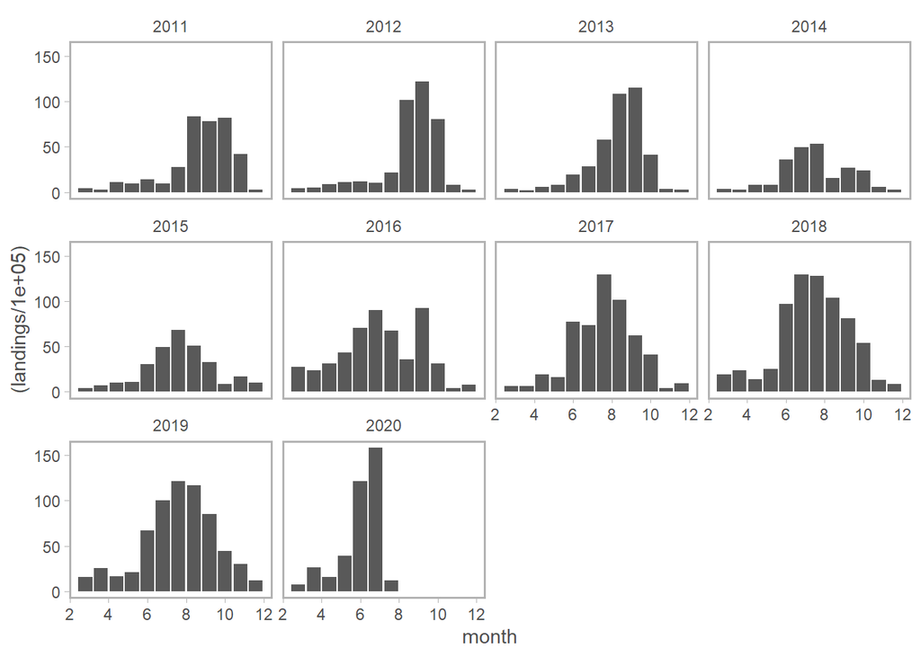

```r
agg_landed_spp <- catch_effort %>%
  group_by(year, month) %>%
  summarise(landings = sum(landed_kg), n = n())%>%
  as.data.frame()

ggplot(agg_landed_spp, aes(x= month, y = (landings/100000)))+
  geom_bar(stat="identity")+
  facet_wrap(~ year) +
  scale_x_continuous(labels=c("2", "4", "6", "8", "10", "12"))+
  theme_sleek()
```

Landings clearly vary over the course of the year with peak landings typically occuring over the summer. There is no uber obvious decline in landings in the spring/summer of 2020 coincident with COVID (note that landings in July should be interpreted with caution due to potentially incomplete reporting). But landings are dominated by Hake, so let’s look at a few of the large landings species individually.

##### **4. What do species specific landings look like over time?**

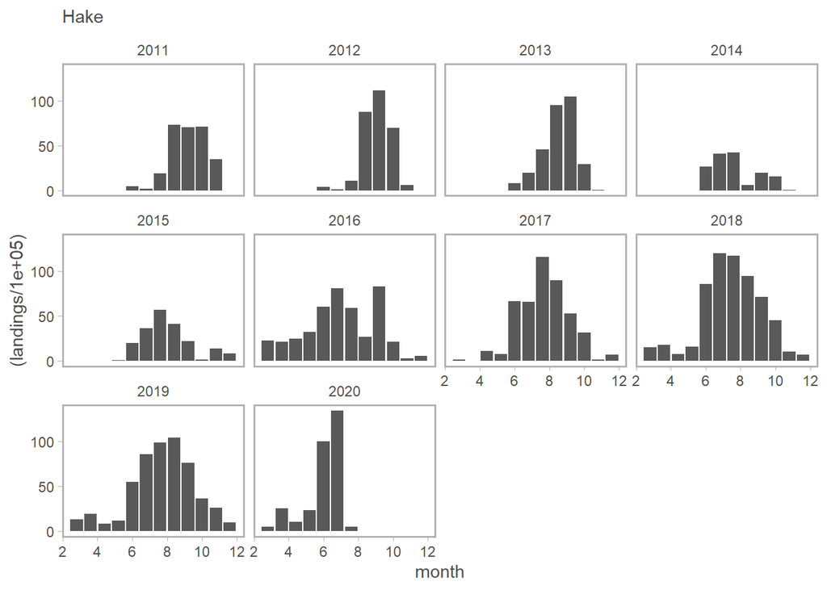

```r
ind_landed_spp <- catch_effort %>%
  group_by(year, month,SPECIES_COMMON_NAME) %>%
  summarise(landings = sum(landed_kg))%>%
  as.data.frame()

ggplot(ind_landed_spp[ind_landed_spp$SPECIES_COMMON_NAME=="PACIFIC HAKE",], aes(x= month, y = (landings/100000)))+
  geom_bar(stat="identity")+
  facet_wrap(~ year) +
  scale_x_continuous(labels=c("2", "4", "6", "8", "10", "12"))+
  theme_sleek()+
  ggtitle("Hake")
```

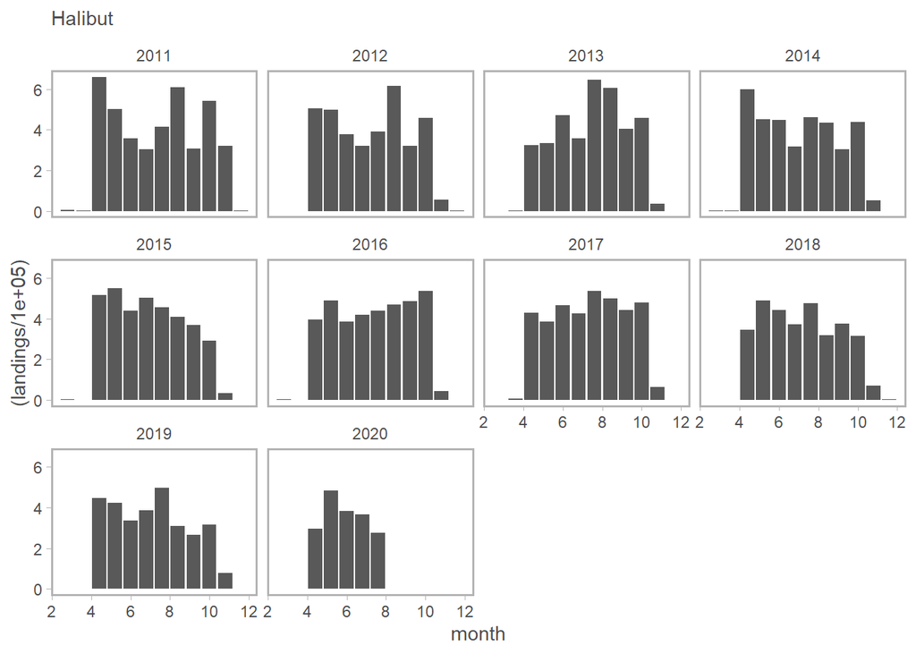

```r
ggplot(ind_landed_spp[ind_landed_spp$SPECIES_COMMON_NAME=="PACIFIC HALIBUT",], aes(x= month, y = (landings/100000)))+
  geom_bar(stat="identity")+
  facet_wrap(~ year) +
  scale_x_continuous(labels=c("2", "4", "6", "8", "10", "12"))+
  theme_sleek()+
  ggtitle("Halibut")
```

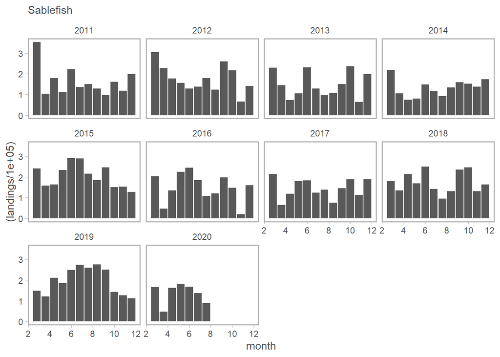

```r
ggplot(ind_landed_spp[ind_landed_spp$SPECIES_COMMON_NAME=="SABLEFISH",], aes(x= month, y = (landings/100000)))+
  geom_bar(stat="identity")+
  facet_wrap(~ year) +
  scale_x_continuous(labels=c("2", "4", "6", "8", "10", "12"))+
  theme_sleek()+
  ggtitle("Sablefish")
```

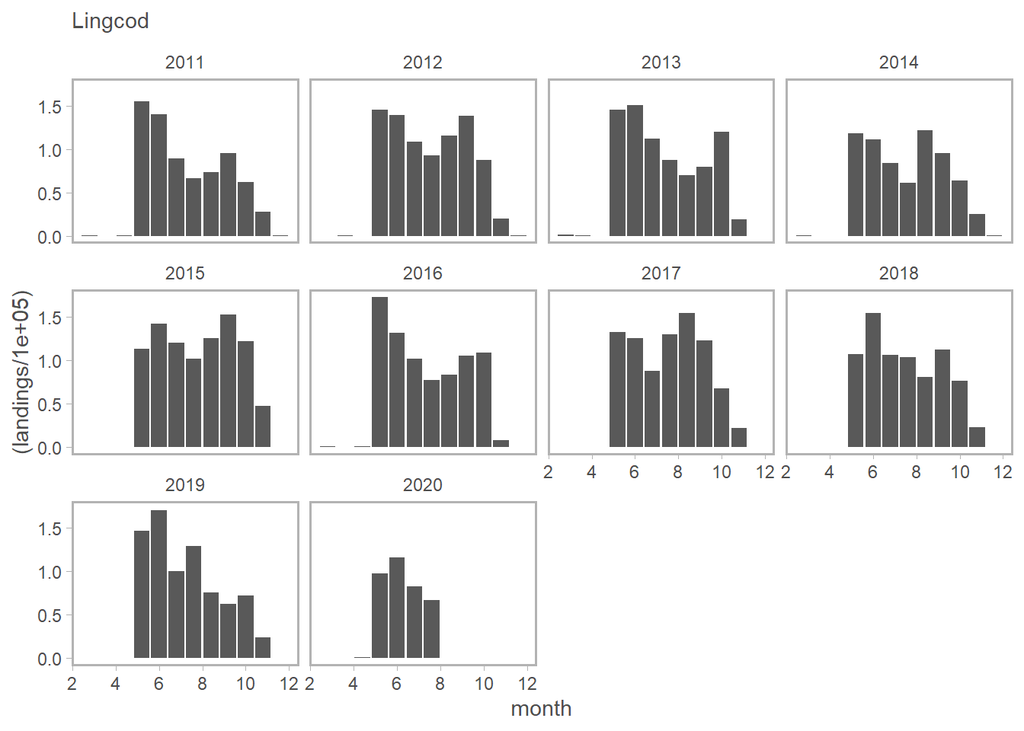

```r
ggplot(ind_landed_spp[ind_landed_spp$SPECIES_COMMON_NAME=="LINGCOD",], aes(x= month, y = (landings/100000)))+
  geom_bar(stat="identity")+
  facet_wrap(~ year) +
  scale_x_continuous(labels=c("2", "4", "6", "8", "10", "12"))+
  theme_sleek()+
  ggtitle("Lingcod")
```

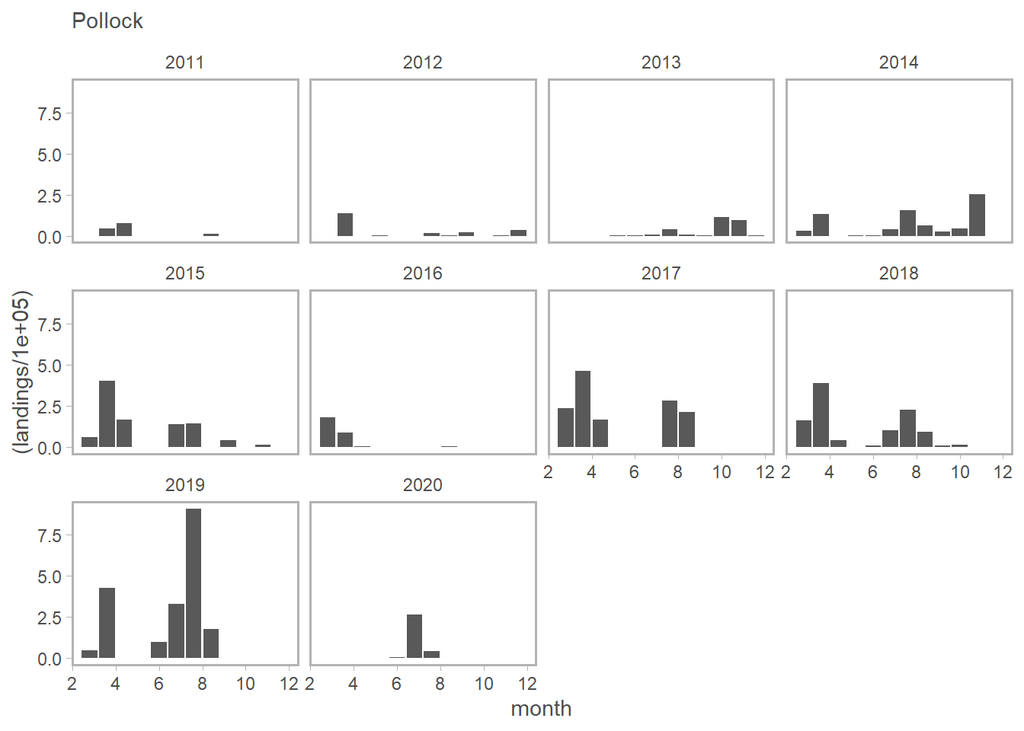

```r
ggplot(ind_landed_spp[ind_landed_spp$SPECIES_COMMON_NAME=="WALLEYE POLLOCK",], aes(x= month, y = (landings/100000)))+
  geom_bar(stat="identity")+
  facet_wrap(~ year) +
  scale_x_continuous(labels=c("2", "4", "6", "8", "10", "12"))+
  theme_sleek()+
  ggtitle("Pollock")
```

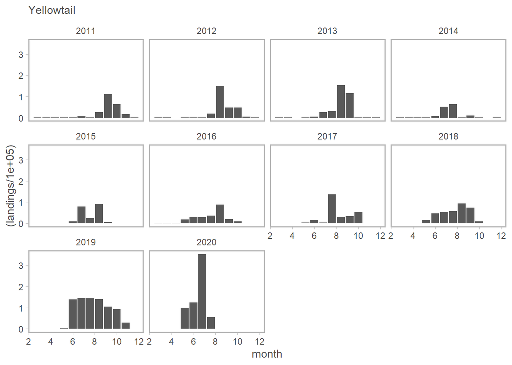

```r
ggplot(ind_landed_spp[ind_landed_spp$SPECIES_COMMON_NAME=="YELLOWTAIL ROCKFISH",], aes(x= month, y = (landings/100000)))+
  geom_bar(stat="identity")+
  facet_wrap(~ year) +
  scale_x_continuous(labels=c("2", "4", "6", "8", "10", "12"))+
  theme_sleek()+
  ggtitle("Yellowtail")
```

No super obvious COVID associated reduction in landings jump out from these figures, but if your squint it looks like landings of Halibut, Sablefish and Lingcod are down a bit since beginning of COVID.

Let’s actually test for a COVID “effect”.

#### 5. Test for a COVID lockdown effect on landings

I specified year and species as random effects (random intercepts; i.e., landings vary by year and species) and also allowed the COVID effect to vary by species (random slope). I fit this model in a Bayesian estimation framework using STAN so as to deal with singularity issues (over fitting?) when fit in a Maximum Likelihood framework. There are admitedly many other ways to think about testing for a COVID effect, this is just a very simple first pass.

Here is a call to fit the model and then summary of model fit.

```r
covid_model <- stan_lmer(log(landed_kg) ~ 0 + gear + covid + (1|year) + (covid|SPECIES_COMMON_NAME),
                         data = covid_period)
summary(covid_model)
```

```
##
## Model Info:
##
##  function:     stan_lmer
##  family:       gaussian [identity]
##  formula:      log(landed_kg) ~ 0 + gear + covid + (1 | year) + (covid | SPECIES_COMMON_NAME)
##  algorithm:    sampling
##  priors:       see help('prior_summary')
##  sample:       4000 (posterior sample size)
##  observations: 67
##  groups:       year (10), SPECIES_COMMON_NAME (9)
##
## Estimates:
##                                                                             mean
## gearBOTTOM TRAWL                                                             4.3
## gearHOOK AND LINE                                                            8.7
## gearMIDWATER TRAWL                                                          11.6
## gearTRAP                                                                     6.8
## covid                                                                       -1.0
## b[(Intercept) year:2011]                                                     0.3
## b[(Intercept) year:2012]                                                     0.4
## b[(Intercept) year:2013]                                                     0.4
## b[(Intercept) year:2014]                                                    -0.2
## b[(Intercept) year:2015]                                                    -0.3
## b[(Intercept) year:2016]                                                    -0.3
## b[(Intercept) year:2017]                                                    -0.5
## b[(Intercept) year:2018]                                                     0.3
## b[(Intercept) year:2019]                                                     0.2
## b[(Intercept) year:2020]                                                     0.0
## b[(Intercept) SPECIES_COMMON_NAME:LINGCOD]                                   1.8
## b[covid SPECIES_COMMON_NAME:LINGCOD]                                        -0.6
## b[(Intercept) SPECIES_COMMON_NAME:PACIFIC_HAKE]                              0.3
## b[covid SPECIES_COMMON_NAME:PACIFIC_HAKE]                                   -0.1
## b[(Intercept) SPECIES_COMMON_NAME:PACIFIC_HALIBUT]                           2.1
## b[covid SPECIES_COMMON_NAME:PACIFIC_HALIBUT]                                -3.4
## b[(Intercept) SPECIES_COMMON_NAME:PACIFIC_OCEAN_PERCH]                      -2.7
## b[covid SPECIES_COMMON_NAME:PACIFIC_OCEAN_PERCH]                             2.7
## b[(Intercept) SPECIES_COMMON_NAME:ROUGHEYE/BLACKSPOTTED_ROCKFISH_COMPLEX]    0.7
## b[covid SPECIES_COMMON_NAME:ROUGHEYE/BLACKSPOTTED_ROCKFISH_COMPLEX]          0.2
## b[(Intercept) SPECIES_COMMON_NAME:SABLEFISH]                                 2.6
```

[output cut: 372 more lines]

```
## b[(Intercept) SPECIES_COMMON_NAME:SPINY_DOGFISH]                          2092
## b[covid SPECIES_COMMON_NAME:SPINY_DOGFISH]                                1980
## b[(Intercept) SPECIES_COMMON_NAME:WALLEYE_POLLOCK]                        1920
## b[covid SPECIES_COMMON_NAME:WALLEYE_POLLOCK]                              4157
## b[(Intercept) SPECIES_COMMON_NAME:YELLOWTAIL_ROCKFISH]                    1844
## b[covid SPECIES_COMMON_NAME:YELLOWTAIL_ROCKFISH]                          3966
## sigma                                                                     2174
## Sigma[year:(Intercept),(Intercept)]                                       1752
## Sigma[SPECIES_COMMON_NAME:(Intercept),(Intercept)]                        1587
## Sigma[SPECIES_COMMON_NAME:covid,(Intercept)]                              2389
## Sigma[SPECIES_COMMON_NAME:covid,covid]                                    1536
## mean_PPD                                                                  3964
## log-posterior                                                              928
##
## For each parameter, mcse is Monte Carlo standard error, n_eff is a crude measure of effective sample size, and Rhat is the potential scale reduction factor on split chains (at convergence Rhat=1).
```

This summary output suggests that (log) landings were lower during the COVID lockdown (see coefficient for “covid” above) than would otherwise have been expected based on history of landings by gear type over the past decade. But this COVID effect is highly uncertain and not “significant” at a 95% credible interval level. Nonetheless, we can calculate the predicted percent change in landings associated with the COVID lockdown as (exp(covid coefficient)-1)*100 which gives a median of a 63% decline in landings (-98% to +897%; 95% credible intervals). I would **interpret this as a lack of evidence for a COVID lockdown effect on groundfish landings inthe Pacific Region**.

If we want a t-statistic associated with the COVID “effect” then we can also fit the model in a Maximum Likelihood framework using lmer. Looks like there are no singularity issues and covid coefficients are very similar to model above.

```r
covid_model <- lmer(log(landed_kg)~0+gear+covid+(1|year)+(covid|SPECIES_COMMON_NAME), data = covid_period)
summary(covid_model)
```

```
## Linear mixed model fit by REML ['lmerMod']
## Formula:
## log(landed_kg) ~ 0 + gear + covid + (1 | year) + (covid | SPECIES_COMMON_NAME)
##    Data: covid_period
##
## REML criterion at convergence: 319.6
##
## Scaled residuals:
##     Min      1Q  Median      3Q     Max
## -2.5783 -0.3315  0.2416  0.5028  2.0801
##
## Random effects:
##  Groups              Name        Variance Std.Dev. Corr
##  year                (Intercept)  0.2524  0.5024
##  SPECIES_COMMON_NAME (Intercept)  5.4570  2.3360
##                      covid       15.3684  3.9203   -0.54
##  Residual                         5.9790  2.4452
## Number of obs: 67, groups:  year, 10; SPECIES_COMMON_NAME, 9
##
## Fixed effects:
##                    Estimate Std. Error t value
## gearBOTTOM TRAWL     4.7637     1.3579   3.508
## gearHOOK AND LINE    8.9859     0.9483   9.476
## gearMIDWATER TRAWL  12.1915     1.2481   9.768
## gearTRAP             7.0944     1.1885   5.969
## covid               -1.2650     2.0186  -0.627
##
## Correlation of Fixed Effects:
##             gBOTTT gHOOAL gMIDWT grTRAP
## gHOOKANDLIN  0.394
## gMIDWATERTR  0.458  0.498
## gearTRAP     0.325  0.639  0.373
## covid       -0.245 -0.319 -0.396 -0.316
```